# PSYC 824: Episode 4

05/02/2021

## Today’s Schedule

- Discussion about Psychology and “Qualitative Designs”!
  - Led by Adriana and Tiara!
  - Cronbach!
  - Morrow!
  - Gergen!
  - Ponterotto and Grieger!
  - Grayman!
- A brief introduction to NVivo!

## The Readings:

- Cronbach, L. (1957). The two disciplines of scientific psychology. *American Psychologist*, *12*(11), 671- 684.
- Morrow, S. L. (2007). Qualitative Research in Counseling Psychology. *The Counseling Psychologist*, *35*(2), 209–235.
- Gergen, K.J. (2014). Pursuing Excellence in Qualitative Inquiry. *Qualitative Psychology*, *1*(1), 49–60.
- Ponterotto, J.G., & Grieger, I. (2007). Effectively Communicating Qualitative Research. *The Counseling Psychologist*, *35*(3), 404–430.
- Grayman, N. (2009). “We Who Are Dark…”: The Black Community According to Black Adults in America: An Exploratory Content Analysis. *Journal of Black Psychology*, *35*(4), 433–455.

## What do Qualitative Analysts **do**?

Qualitative analysis is a matter of keeping track of:

- What you are **doing**:
  - Documenting the research process
  - Documenting the participants and information sources
  - Transcribing and editing your transcription
  - Archiving the raw data

## What do Qualitative Analysts **do**?

Qualitative analysis is a matter of keeping track of:

- What you are **thinking, hearing, seeing, and feeling**:
  - Field notes log
  - Analytic memos
  - Research diary

## What do Qualitative Analysts **do**?

Qualitative analysis is a matter of keeping track of:

- What you are **finding**:
  - Getting an overall sense of the data
  - Coding the data more closely
  - Expanding and merging codes (e.g. topics and themes)
  - Writing analytic memos about findings and interpretations
  - Identifying relationships in your data
  - Monitoring shifts in your “positionality”
  - Assessing your data’s relationships to external contexts

## How do you keep track?

**DOCUMENT EVERYTHING**

- Keep a clean copy of the original research design/proposal and note any changes made from that plan.
- Comment on methods that worked **and** those that did not.
- Keep blank copies of all interview protocols, discussion outlines, questionnaires, etc.
- Keep a tentative **and actual** time line and budget.
- Document all your methods and instruments:
  - How did you find your participants?
  - How did you get permission to interview them?
  - What kind of guarantees of confidentiality or anonymity did you provide?
  - How did you get access to archival materials?

## Marking Up the Text

- Read for the **overall plot** or story told by the participant
  - Write this out after reading the entire text on a separate piece of paper
- Read for **your own** response to the story
  - Mark up the text in blue pen in the *left margin*
- Read to understand how the **participant** experiences, feels, and speaks about themselves
  - Mark up the text in red pen in the *right margin*
- Memo your thoughts about particular participants before reading across texts
  - Write this out as your are reading, on a separate piece of paper.

Adapted from Doucet and Mauthner, 1998.

## Qualitative Coding

- **Goal**: to make sense of your mass of data through recognition of patterns and themes within and across texts.
  - To describe, interpret themes, or theorize on how patterns fit together
- An **iterative process** – what you find can influence what you look for next and how you might reinterpret what you already found!

**Coding Tips**:

- Name, don’t summarize.
- Name fully (e.g., statements can have more than one code).
- Use consistent coding scheme (tracked in a “code book”).

## Topic Linking Chart

| Theme | Text1 | Text2 | Text3 | Text4 | Text5 |
| --- | --- | --- | --- | --- | --- |
| - | A | A | - | A | A |
| Minor | B | - | B | - | - |
| Major | C | C | C | C | C |
| - | - | D | D | D | - |
| Unique | E | - | - | - | - |

Adapted from Tesch, 1990.

## How are themes linked?

- **Hierarchical**: X is a *kind* of Y
- **Sequence**: X is a *step or stage* in Y
- **Attribution/Nested**: X is a *characteristic* of Y
- **Cause and Effect**: X is a *result* of Y
- **Rationale**: X is a *reason* for doing Y

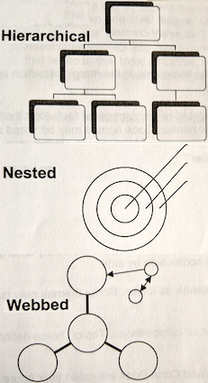

## Computer-Assisted Qualitative Data Analysis Software (CAQDAS)

- Text Retrievers (automatic collection)
- Text-base Managers (sorting/editing)
- Code-and-Retrieve Programs (extract/juxtapose/associate)
- Code-Based Theory Builders (trees/models/thematic organization)
- Conceptual Network Builders (conceptual graphics)

“You Think, They Do”

## Questions to Ask of CAQDAS:

- Can more than one code be attached to a text segment? Can text segments overlap? Is it easy to change, delete, add individual codes?
- Can you search for multiple codes or particular code sequences?
- Can you search selectively, only through certain texts?
- How easy is it to import, create, save, retrieve files?
- How are memos handled?
- How easy is it to learn?
- Will it run on my computer? Is there technical support available?
- Where is it available? How much does it cost?
- Will it perform all the functions I need?

## So Many Choices!

> NVivo, ATLAS.ti, Provalis Research Text Analytics, Quirkos, MAXQDA, Dedoose, Raven’s Eye, Qiqqa, webQDA, HyperRESEARCH, Transana, F4analyse, Annotations, Datagrav, and more!

List from: predictiveanalyticstoday.com/top-qualitative-data-analysis-software/

## NVivo 12

- Originally released as NUD*IST (1981!): “Non-numerical Unstructured Data Indexing, Searching and Theorizing”.
- Name is a reference to “In Vivo” data (vs. “In Vitro”).
- Developed by Lyn and Tom Richards, who formed QSR International.
- Commonly used program; available on Windows and Mac OS X.

Version 12 is available through SFU:

- http://www.lib.sfu.ca/about/branches-depts/rc/research/software/nvivo
- https://www.lib.sfu.ca/about/branches-depts/rc/software-data-dh/software/nvivo/getting-started
- https://www.lib.sfu.ca/about/branches-depts/rc/software-data-dh/software/nvivo/download/instructions

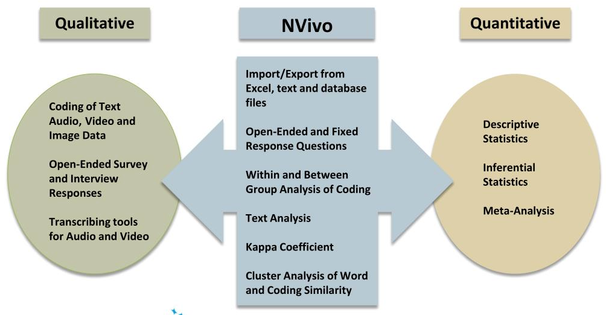

## The 5 Steps:

1. **Gather the Ingredients**: Import all reference sources to NVivo and create memos.
2. **Code the References**: Create nodes, coding strips.
3. **Create cases** to classify and store descriptive information: Add attributes.
4. **Run queries** and analyze coded data.
5. **Present findings** and prepare report.

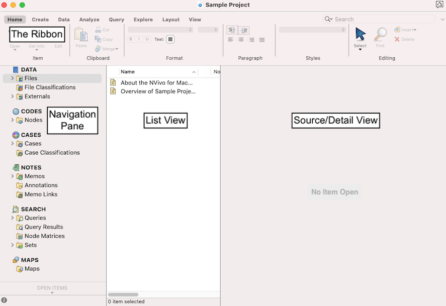

Some important notes:

- **Data** represents the actual files you are importing into your project
  - Often useful to group by source
  - Can apply “classifications” to incorporate meta-data
- **Cases** represent **units of observation**: can be people, places, organizations, events or other entities! Cases have:
  - a **classification** (e.g., Person, Organization, Place); and,
  - one or more **attributes** (e.g., age, gender, location), which are stored in “Case Classifications” or a spreadsheet.
- The **Query Ribbon** hides some very useful tools, such as the ability to run: text searches, word frequencies, coding searches, matrix coding searches, cross-tabulations, and coding comparisons!

## Tutorials and Other Links:

- QSR’s NVivo 12 help page for Mac: https://help-nv.qsrinternational.com/12/mac/v12.1.98-d3ea61/Content/welcome.htm
- QSR’s NVivo 12 help page for Windows: https://help-nv.qsrinternational.com/12/win/v12.1.98-d3ea61/Content/welcome.htm
- QSR’s Help Forums: https://forums.nvivobyqsr.com/?_ga=2.175004778.975483198.1583162118-1098817361.1582235989
- Jackson, K. & Bazeley, P. (2019). *Qualitative data analysis with NVivo*, 3rd Ed. Sage Publications.
- Dr. Bazeley’s Website: http://researchsupport.com.au/

## Next Time on…

- Discussion led by Nikola!

**Readings on “Ethics in Psychological Studies”:**

- Rosenthal, R. (1994). Science and Ethics in Conducting, Analyzing, and Reporting Psychological Research. *Psychological Science*, *5*(3), 127-134.
- John, L.K., Loewenstein, G., & Prelec, D. (2012). Measuring the Prevalence of Questionable Research Practices with Incentives for Truth Telling. *Psychological Science*, *23*(5), 524–532.
- Simmons, J.P., Nelson, L.D., & Simonsohn, U. (2011). False-Positive Psychology: Undisclosed Flexibility in Data Collection and Analysis Allows Presenting Anything as Significant. *Psychological Science*, *22*(11), 1359–1366.
- South African San Institute (2017). *San Code of Research Ethics*. Available from: http://trust-project.eu/wp-content/uploads/2017/03/San-Code-of-RESEARCH-Ethics-Booklet-final.pdf